# xv20230817_mutations_analysis

x.vergara

2023-08-24

I will explore the data that I received from Mathijs and proccess it as we did previously for BRCA2mut tumors

```r
knitr::opts_chunk$set(root.dir = '/home/x.vergara/XV_P3_ChromDSBScreen/xv_CRISPR_screen_figures/rmarkdown/xv20210920_paper_scripts/short_version/knit_html/')

StartTime <-Sys.time()
library(knitr)

# 8-digit Date tag:
Date <- substr(gsub("-","",Sys.time()),1,8)

#Change in.dir accordingly
in.dir <- "/home/x.vergara/XV_P3_ChromDSBScreen/xv_CRISPR_screen_figures/"

#Check if output contain datetag
saveRDS_proof <- function(object, file) {
  if (grepl(Date, file) == T) {
    saveRDS(object, file)
  }
  else {
    print("Incorrect datetag!")
  }
}

#Read rds check through different versions
readRDS_proof <- function(path, pat) {
  full.path <- paste0(in.dir, path)
  document_path <- rstudioapi::getSourceEditorContext()$path %>% str_split(pattern = "/") %>% unlist()
  document_name <- document_path[length(document_path)]
  sys_time <- Sys.time()

  if(file.exists(full.path) == T){
    if(paste0(in.dir,path) != getwd()){
      setwd(paste0(in.dir, path))
  }
    file.list <- list.files(pattern = pat)
    correct_file <- str_sort(file.list, decreasing = T)[1]
    print(correct_file)
    write(c(document_name,as.character(sys_time) ,"Input", correct_file), file = paste0(in.dir,"log"), ncolumns = 4, sep = "\t", append = T)
    readRDS(correct_file)

  }
  else{
  setwd(path)
  file.list <- list.files(pattern = pat)
  correct_file <- str_sort(file.list, decreasing = T)[1]
  print(correct_file)
  write(c(document_name, as.character(sys_time),"Input", correct_file),file = paste0(in.dir,"log"), ncolumns = 4, sep = "\t", append = T)
  readRDS(correct_file)
  }
}
```

## Libraries:

```r
library(readxl)
library(tidyverse)
library(GenomicRanges)
library(rtracklayer)
library(ggbeeswarm)
```

#Import indel data

```r
setwd(in.dir)
#Import data for indels classified by state
#BRCA2 mut: From paper
BRCA2_indel_files <- list.files(path = "import/xv20220915_INDEL_data_mathijs/xv20220920_CLASS_mathijs_data/BRCA2",full.names = T)
BRCA2_indel_data <- map_dfr(BRCA2_indel_files, function(x) {
  read.delim(x, header = T) %>%
    mutate(sample = gsub(".class","",gsub("import/xv20220915_INDEL_data_mathijs/xv20220920_CLASS_mathijs_data/BRCA2/","",x)),
           driver_mut = "BRCA2")
})
#HNSCC mut: From paper
HNSCC_indel_files <- list.files(path = "import/xv20220915_INDEL_data_mathijs/xv20220920_CLASS_mathijs_data/HNSC",full.names = T)
HNSCC_indel_data <- map_dfr(HNSCC_indel_files, function(x) {
  read.delim(x, header = T) %>%
    mutate(sample = gsub(".class","",gsub("import/xv20220915_INDEL_data_mathijs/xv20220920_CLASS_mathijs_data/HNSC/","",x)),
           driver_mut = "CTR")
})

#Function to import all the data
#List of all driver mutations
driver_mutations_indels <- list.files(path = "/DATA/projects/DSBrepair/data/xv20230818_PCAWG_data_revision/DATA_PCAWG/INDEL/CLASSIFIED", full.names = T)

indel_all_proteins <- map_dfr(driver_mutations_indels, function(y) {
  #Import all data for a single driver mutation
protein_file_names <- list.files(path = y, full.names = T, pattern = ".type")
one_protein_data <-map_dfr(protein_file_names, function(x) {
  read_delim(file = x) %>%
    mutate(f = gsub(paste0("/DATA/projects/DSBrepair/data/xv20230818_PCAWG_data_revision/DATA_PCAWG/INDEL/CLASSIFIED/"),"",x)) %>%
    separate(f, into = c("driver_mut","sample"), sep = "/") %>% #Crate a variable calle driver_mut, which is the protein KO
    mutate(sample = gsub(".somatic.indel.type","", sample)) #Create a column called sample which is tumor identifier
})
})

#Bind all three data frames (all driver mutations and control data)
indell_all_tumor_data <- bind_rows(BRCA2_indel_data, HNSCC_indel_data, indel_all_proteins)
```

#Are there samples represented twice?

```r
#Indel data
repeated_samples <- indell_all_tumor_data %>%
  select(sample) %>%
  distinct() %>%
  dplyr::group_by(sample) %>%
  dplyr::summarise(count = n())

#filter repeated
repeated_samples %>% filter(count > 1)
```

```
## # A tibble: 0 × 2
## # … with 2 variables: sample <chr>, count <int>
```

```r
print("There are not repeated tumors assigned twice")
```

```
## [1] "There are not repeated tumors assigned twice"
```

#Summary of imported indel files

```r
#Summary text for nuber of indels
print(paste("This script imported a total of",
            nrow(indell_all_tumor_data),
            "indels from",
            length(unique(indell_all_tumor_data$driver_mut)),
            "different genetic backgrounds and",
            length(unique(indell_all_tumor_data$sample)),
            "human tumor genomes."))
```

[output not shown]

#CONCLUSION: Indel data can also be imported and merged with BRCA2 and CTR datasets

#Plot number of indels per human genome

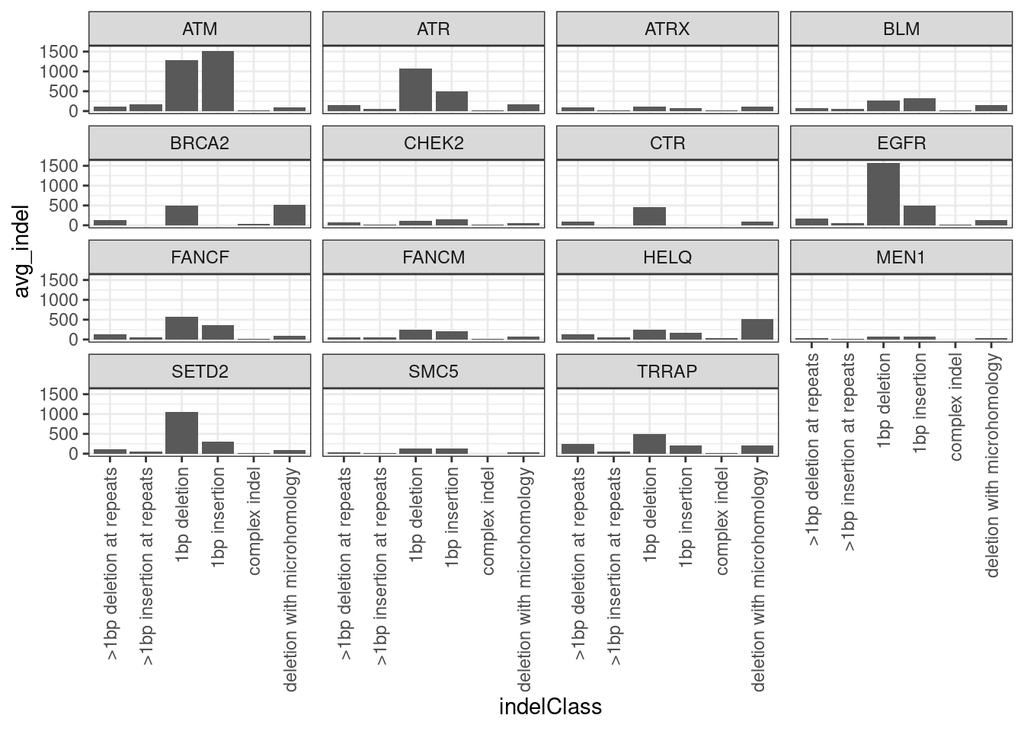

```r
#Plot indel summary per human genome
indels_relative_to_human_genome <- indell_all_tumor_data %>%
  dplyr::group_by(sample, driver_mut, indelClass) %>%
  dplyr::summarise(counts = n()) %>%
  ungroup() %>%
  dplyr::group_by(driver_mut, indelClass) %>%
  dplyr::summarise(avg_indel = mean(counts))
#Plot total SV summary of all tumors
ggplot(indels_relative_to_human_genome) +
  geom_col(aes(indelClass,avg_indel)) +
  facet_wrap(~ driver_mut) +
  theme_bw() +
  theme(axis.text.x = element_text(angle = 90,
                                   hjust = 1,
                                   vjust = 0.5))
```

#Import qualitative data

```r
pcaw_TCGA_donor <- read_delim("/DATA/projects/DSBrepair/data/xv20230818_PCAWG_data_revision/DATA_PCAWG/INFO/pcawg_TCGA_to_donorID.txt")
selection <- read_delim("/DATA/projects/DSBrepair/data/xv20230818_PCAWG_data_revision/DATA_PCAWG/INFO/selection.txt")
#Combine them
tumor_info <- left_join(pcaw_TCGA_donor,selection, c("TCGA_ID" = "sample_id")) %>% separate(ttype, into = c("tissue","type"), remove = F)
```

#CONCLUSION: Tumor info is combined in a single data table

#Add tumor data to indel and summaryse number per driver, tumor type and tissue

```r
#Indel data
indel_tumors_info <- left_join(indell_all_tumor_data, tumor_info, c("sample"="TCGA_ID"))

#Summary table
summary_table <- indel_tumors_info %>%
  select(driver_mut, type, tissue, sample) %>%
  distinct()

#Number of samples per drivers
drivers_summary <- summary_table %>%
  dplyr::group_by(driver_mut) %>%
  dplyr::summarise(driver_n = n()) %>%
  arrange(desc(driver_n))

#Pull vector type
driver_desc_order <- drivers_summary %>% pull(driver_mut)

#Number of samples per tumor type
type_summary <- summary_table %>%
  dplyr::group_by(type,tissue) %>%
  dplyr::summarise(type_n = n()) %>%
  arrange(desc(type_n))
#Number of samples per tissue
tissue_summary <- summary_table %>%
  dplyr::group_by(tissue) %>%
  dplyr::summarise(tissue_n = n()) %>%
  arrange(desc(tissue_n))

#Pull vector tissue
tissue_desc_order <- tissue_summary %>% pull(tissue)

#Summary table of total
summary_table_indels <- summary_table %>%
  left_join(drivers_summary) %>% #First drivers
  left_join(type_summary) %>% #Then type
  left_join(tissue_summary) #Third per tissue
```

#Plot tissue per driver mutation

```r
#Prepare data frame for this classification
classifier_table <- summary_table %>%
  dplyr::group_by(driver_mut, tissue, type) %>%
  dplyr::summarise(classifier_n = n())
```

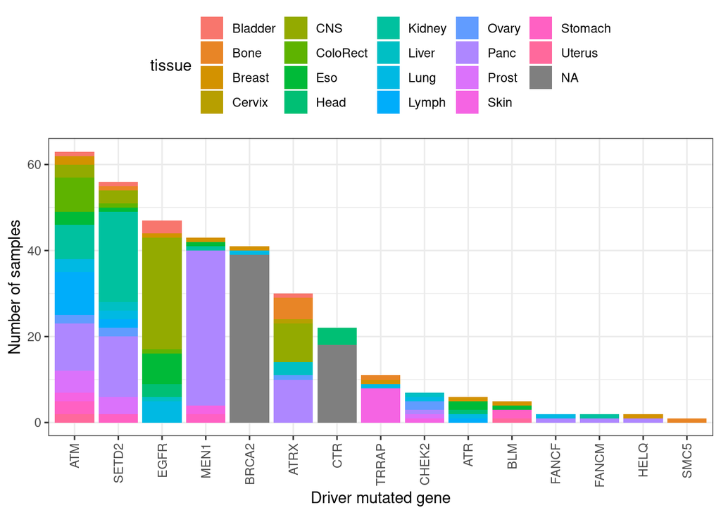

```r
#Plot samples per tumor
ggplot(classifier_table) +
  geom_col(aes(fct_relevel(driver_mut, driver_desc_order),
               classifier_n,
               fill = tissue)) +
  theme_bw() +
  theme(axis.text.x = element_text(angle = 90,
                                   hjust = 1,
                                   vjust = 0.5),
        legend.position = "top") +
  ylab("Number of samples") +
  xlab("Driver mutated gene")
```

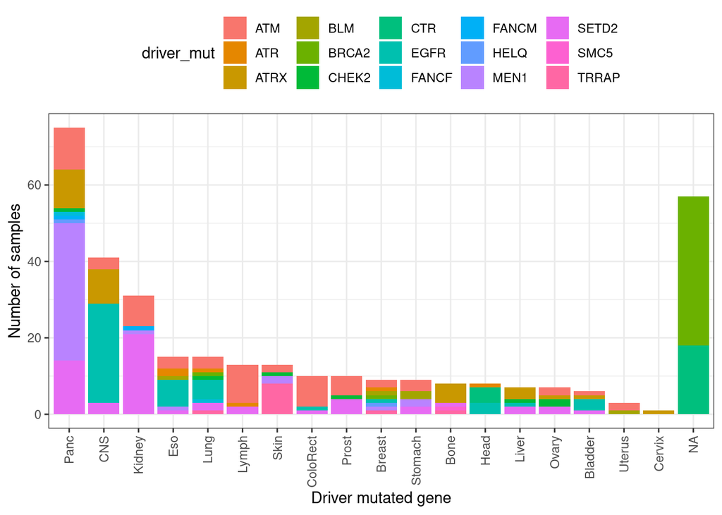

```r
#Plot samples per tumor
ggplot(classifier_table) +
  geom_col(aes(fct_relevel(tissue, tissue_desc_order),
               classifier_n,
               fill = driver_mut)) +
  theme_bw() +
  theme(axis.text.x = element_text(angle = 90,
                                   hjust = 1,
                                   vjust = 0.5),
        legend.position = "top") +
  ylab("Number of samples") +
  xlab("Driver mutated gene")
```

#Select only the deletions, as in the paper

```r
# Selected deletion classes used in paper
deletion_classification <- BRCA2_indel_data %>%
  select(indelClass,indelSubClass,indelRepeats,CLASS) %>%
  distinct() %>%
  mutate(CLASS = case_when(indelClass == ">1bp deletion at repeats" &
                             indelSubClass == "5+" &
                             indelRepeats == "1" ~ "cNHEJ", #Add cNHEJ category
                           T ~ CLASS)) #Keep rest the same

#Cross this data frame with all indels
deletion_classified <- indel_tumors_info %>%
  select(-CLASS) %>% #Remove old clasification (without cNHEJ)
  left_join(deletion_classification) %>% #Left join deletion classification used in paper
  filter(!is.na(CLASS)) #Filter out all data that was not used in the paper
```

#Calculate the number of indels per class and sample

```r
#Quick control table to check if there are any empty values
indels_per_sample_dcast <- deletion_classified %>%
  reshape2::dcast(sample+driver_mut+tissue+type ~ CLASS, fun.aggregate = length)
#Quick check: Is there any empty category?
print(paste("In this dataframe there are",
            sum(indels_per_sample_dcast[5:9] == 0),
            "empty deletion classes."))
```

```
## [1] "In this dataframe there are 21 empty deletion classes."
```

```r
#Create the final table
indels_per_sample <- indels_per_sample_dcast %>%
  reshape2::melt(value.name = "counts",variable.name = "CLASS") %>%
  mutate(pseudo_counts = counts + 1) %>% #Add a pseudocounts
  right_join(summary_table_indels)
print(paste("Without a psheudocount, there are ",
            sum(indels_per_sample$counts == 0),
            ". But, after adding a pseudocount, in this dataframe there are",
            sum(indels_per_sample$pseudo_counts == 0),
            "empty deletion classes."))
```

```
## [1] "Without a psheudocount, there are  21 . But, after adding a pseudocount, in this dataframe there are 0 empty deletion classes."
```

#First QC: How much deletion classes change per tissue?

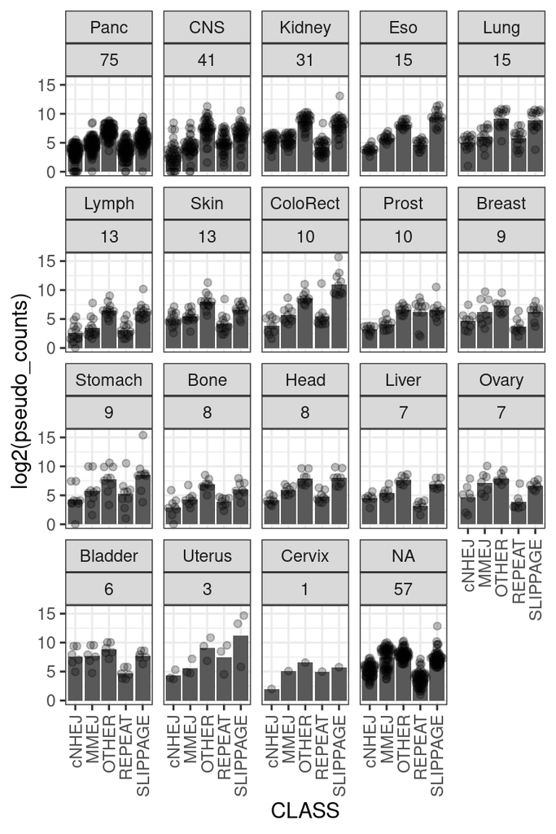

```r
#
ggplot(indels_per_sample,aes(CLASS,log2(pseudo_counts))) +
  stat_summary(geom = "bar",fun = "mean") +
  geom_quasirandom(alpha = 0.25) +
  facet_wrap(~ reorder(tissue, dplyr::desc(tissue_n)) + tissue_n) +
  theme_bw() +
  theme(axis.text.x = element_text(angle = 90,
                                   hjust = 1,
                                   vjust = 0.5))
```

#CONCLUSION: There is no clear changes from tissue to tissue, when it comes to mutation accumulation. The spread acrtoss samples is much bigger than from tissue to tissue.

#Calculate per driver gene

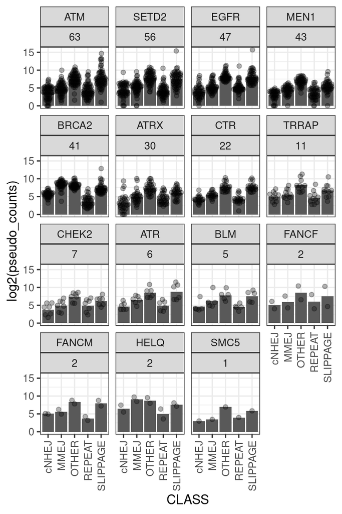

```r
#
ggplot(indels_per_sample,aes(CLASS,log2(pseudo_counts))) +
  stat_summary(geom = "bar",fun = "mean") +
  geom_quasirandom(alpha = 0.3) +
  facet_wrap(~ reorder(driver_mut, dplyr::desc(driver_n)) + driver_n) +
  theme_bw() +
  theme(axis.text.x = element_text(angle = 90,
                                   hjust = 1,
                                   vjust = 0.5))
```

#CONCLUSION: In log2 scale there are not big differences in the amount of mutations per tumor

#Plot control data

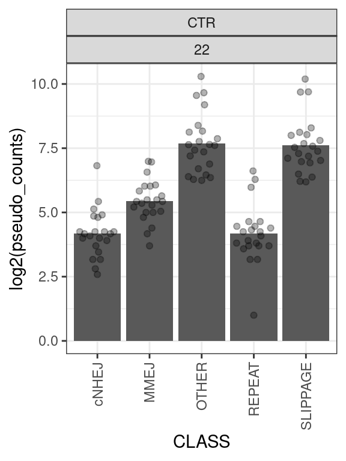

```r
ggplot(indels_per_sample %>% filter(driver_mut == "CTR"),
       aes(CLASS,log2(pseudo_counts))) +
  stat_summary(geom = "bar",fun = "mean") +
  geom_quasirandom(alpha = 0.3) +
  facet_wrap(~ reorder(driver_mut, dplyr::desc(driver_n)) + driver_n) +
  theme_bw() +
  theme(axis.text.x = element_text(angle = 90,
                                   hjust = 1,
                                   vjust = 0.5))
```

#Plot control normalized data (as in figure supplementary)

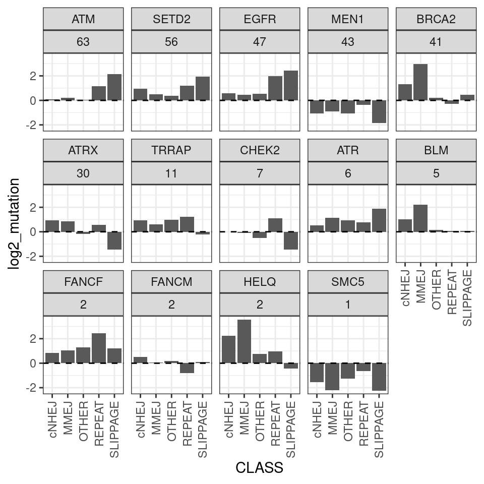

```r
#NOTE: This figure is tricky to interpret as the control set is not the matching negative control for all tissues
#Control data mean values
ctr_data <- indels_per_sample %>%
  filter(driver_mut == "CTR") %>%
  dplyr::group_by(CLASS) %>%
  dplyr::summarise(mean_ctr_counts = mean(pseudo_counts))

#Data table with log2 ratios
difference_indels_per_driver <- indels_per_sample %>%
  dplyr::group_by(driver_mut, CLASS) %>%
  dplyr::summarise(mean_counts = mean(pseudo_counts)) %>%
  left_join(ctr_data) %>%
  mutate(log2_mutation = log2(mean_counts/mean_ctr_counts)) %>%
  left_join(drivers_summary)
#Plot differences
ggplot(difference_indels_per_driver %>% filter(driver_mut != "CTR")) +
  geom_col(aes(CLASS, log2_mutation)) +
  facet_wrap(~ reorder(driver_mut, dplyr::desc(driver_n)) + driver_n, ncol = 5)+
  theme_bw() +
  theme(axis.text.x = element_text(angle = 90,
                                   hjust = 1,
                                   vjust = 0.5)) +
  geom_hline(yintercept = 0, linetype = 2)
```

CONCLUSION: This is tricky without a proper control tumor set. Mutation levels change greatly from tumor to tumor and not always makes sense.

#An alternative to this plot is to calculate MMEJ/NHEJ ratio and use this as a metric

```r
# Calculate ∆log2 MMEJ:NHEJ ratio
ratio_calculation <- indels_per_sample_dcast %>%
  mutate(log2_ratio = log2((MMEJ + 1 )/(cNHEJ + 1))) %>%
  left_join(summary_table_indels)
```

#Again QC: How much the ratio changes per tissue?

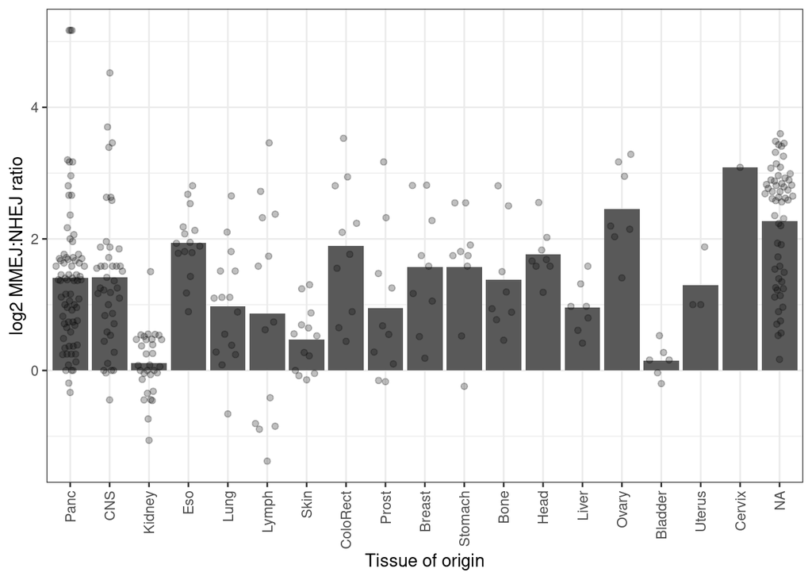

```r
ggplot(ratio_calculation,aes(reorder(tissue, dplyr::desc(tissue_n)),log2_ratio)) +
  stat_summary(geom = "bar",fun = "mean") +
  geom_quasirandom(alpha = 0.25) +
  theme_bw() +
  theme(axis.text.x = element_text(angle = 90,
                                   hjust = 1,
                                   vjust = 0.5)) +
  xlab("Tissue of origin") +
  ylab("log2 MMEJ:NHEJ ratio")
```

#There are quite substantial differences in the ∆log2 MMEJ:NHEJ data between tissues. This might bias pathway balance, mainly for tumors with low samples number

#Calculate ratio per tumor sample, see how noisy the data is

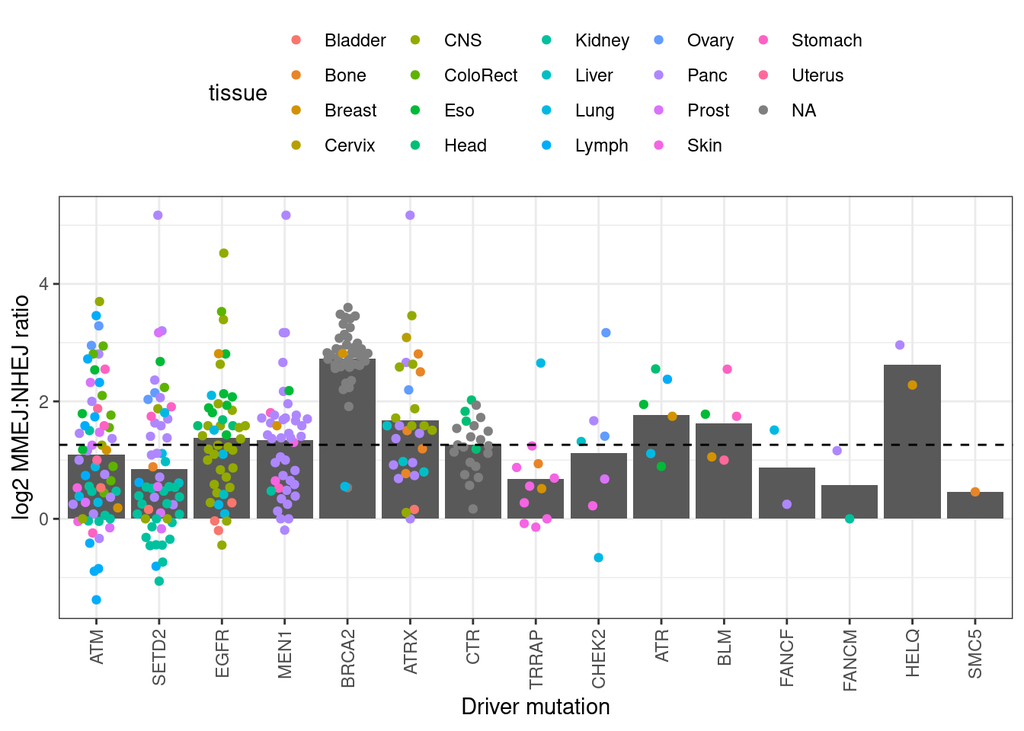

```r
#Control mean counts
control_mean_counts <- ratio_calculation %>% filter(driver_mut == "CTR") %>% pull(log2_ratio) %>% mean()

#Calculate statistical test to test for mean changes
wilcox_test_tumor <- map_dfr(driver_desc_order, function(x){
  single_prot <- ratio_calculation %>% filter(driver_mut == x) %>% pull(log2_ratio)
  ctr_prot <- ratio_calculation %>% filter(driver_mut == "CTR") %>% pull(log2_ratio)
  if (length(single_prot) > 2) {
  wilcox.test(single_prot,ctr_prot) %>% broom::tidy() %>% mutate(driver_mut = x)
  }
})

#p-value adjustment
wilc_test_adjust <- wilcox_test_tumor %>%
  filter(driver_mut != "CTR") %>%
  mutate(fdr = p.adjust(p.value, method = "BH")) %>%
  filter(fdr < 0.1)

#
ggplot(ratio_calculation,aes(reorder(driver_mut, dplyr::desc(driver_n)),log2_ratio)) +
  stat_summary(geom = "bar",fun = "mean") +
  geom_quasirandom(aes(color = tissue)) +
  geom_hline(yintercept = 1.26, linetype = 2) +
  theme_bw() +
  theme(axis.text.x = element_text(angle = 90,
                                   hjust = 1,
                                   vjust = 0.5),
        legend.position = "top") +
  xlab("Driver mutation") +
  ylab("log2 MMEJ:NHEJ ratio")
```

#CONCLUSION: Proteins change mutation pattern as predicted by the screen. But, BRCA2 is the clearest example. This might be biased by the fact that all samples in BRCA2null come from a very curated dataset, while everything else contains all sorts of tumors.

#Import LADs data

```r
setwd(in.dir)
# LAD domains
LAD_atlas <- as.data.frame(read.table("import/xv20220329_LAD_atlas_OSF.bed.gz",header = FALSE, sep="\t",stringsAsFactors=FALSE, quote=""))
colnames(LAD_atlas) <- c("chr","start","end","length","strand","LAD_class")

#LAD_length plot control
LAD_length_tibble <- LAD_atlas %>% mutate(LAD_length = end - start)
```

#Map indel data to LAD status

```r
#Create function to call unique LADs
LAD_atlas_ranges <- makeGRangesFromDataFrame(LAD_atlas, keep.extra.columns = T) #Make LADs into GR ranges

#Function to map mutations in unique LADs or iLADs
LADs_status_call_indel <- function(x) {
  print(dim(x))
  mutations_GR <- makeGRangesFromDataFrame(x, keep.extra.columns = T) #Make a GR object with the coordinated of the deletion
  LAD_overlaps <- findOverlaps(LAD_atlas_ranges,mutations_GR) #Find overlaps between deletions and LAD states
  LAD_overlaps_dt <- tibble(x[subjectHits(LAD_overlaps),], LAD_status =  LAD_atlas[queryHits(LAD_overlaps),6]) #Extract the LAD_status of the mapped deletion
  LAD_counts <- LAD_overlaps_dt %>% dplyr::group_by(tumor_id, mutation_id, LAD_status) %>% dplyr::summarize(count = n()) #How many different overlaps a deletions has. count = 1 -> single map, if bigger means goes over border
  single_LADs_iLADs <-LAD_counts %>% reshape2::dcast(tumor_id + mutation_id ~ LAD_status, fill = 0) #Filter these that are called only once
  #LAD_overlaps_dt %>% right_join(single_LADs_iLADs) #Keep only uniquely called
}

#Prepare the data table for mapping
mutation_location_all_tumor <- deletion_classified %>% #Sporadic HNSCC
    mutate(chr = CHR, start = POSITION, end = POSITION + 1,mutation_id = 1:nrow(.)) %>% #change chr format
  select(chr, start, end, tumor_id = sample, mutation_id, indelClass, indelSubClass, indelRepeats, CLASS, driver_mut) #select needed columns

#Run function (table A)
indel_LAD_maps <- LADs_status_call_indel(mutation_location_all_tumor) %>%
  left_join(mutation_location_all_tumor) #419991 uniquely mapped indels in all tumors
```

```
## [1] 419991     10
```

#Quick check of mutation accumulation per driver mutation

```r
#Calculate the number of indels per LAD class
summary_table_driver <- indel_LAD_maps %>% dplyr::group_by(CLASS, driver_mut,tumor_id) %>% dplyr::summarise(tot_cLAD = sum(cLAD, na.rm = T),
                                                                                     tot_ciLAD = sum(ciLAD, na.rm = T),
                                                                                     tot_fLAD = sum(fLAD, na.rm = T),
                                                                                     tot_fiLAD = sum(fiLAD, na.rm = T))
```

```r
#Transform data frame and select only constitutive LAD and iLAD
plot_mutation_chromatin_state_tumor <- summary_table_driver %>% na.omit() %>% select(CLASS,sample = tumor_id, cLAD  = tot_cLAD, ciLAD = tot_ciLAD, driver_mut) %>% reshape2::melt() %>% left_join(summary_table_indels)
#Print heat of mutation
head(plot_mutation_chromatin_state_tumor)
```

```
##   CLASS                               sample driver_mut variable value     type
## 1 cNHEJ 00aa769d-622c-433e-8a8a-63fb5c41ea42        ATM     cLAD     2  AdenoCA
## 2 cNHEJ 04b570c2-3224-4e9b-81cc-089b4a7ff07a        ATM     cLAD     0      CLL
## 3 cNHEJ 063cfacf-9933-4a2d-8921-0aeb76e12779        ATM     cLAD     5      RCC
## 4 cNHEJ 0cf9bbc2-cbd5-4b64-8d90-cfa416307b39        ATM     cLAD     4  AdenoCA
## 5 cNHEJ 142b6dbf-c943-4a7d-8ab6-13a975f48d7a        ATM     cLAD     5 Melanoma
## 6 cNHEJ 14bf9bfb-14d6-4cac-a556-828f680e8a15        ATM     cLAD     7  AdenoCA
##     tissue driver_n type_n tissue_n
## 1 ColoRect       63     10       10
## 2    Lymph       63     12       13
## 3   Kidney       63     29       31
## 4     Panc       63     17       75
## 5     Skin       63     13       13
## 6     Lung       63      9       15
```

#Control calculation: Number of mutations per sample. Are there enough mutations to calculate it per tumor

```r
#Dcast per LAD state
samples_with_zeroes <- plot_mutation_chromatin_state_tumor %>%
  distinct() %>%
  reshape2::dcast(driver_mut + variable + sample ~ CLASS)

#How many are empty
print(paste("In this data, frame there are a total of",
            sum(samples_with_zeroes[c(4,5)] == 0, na.rm = T),
            "chromatin-sample with no mutation out of a total of",
            2*nrow(samples_with_zeroes[c(4,5)])))
```

```
## [1] "In this data, frame there are a total of 154 chromatin-sample with no mutation out of a total of 1352"
```

#CONCLUSION: There is not enough data to calculate log2 MMEJ:NHEJ per sample and then average it. I have to calculate per driver mutation.

#Calculate ratio per driver mutation (same as in paper)

```r
# Prepare data frame per driver mutation.
LAD_values_driver <- plot_mutation_chromatin_state_tumor %>%
  reshape2::dcast(driver_mut + variable ~ CLASS, fun.aggregate = sum) %>%
  mutate(ratio = log2(MMEJ/cNHEJ)) %>%
  left_join(drivers_summary)
```

#Calculate control balances

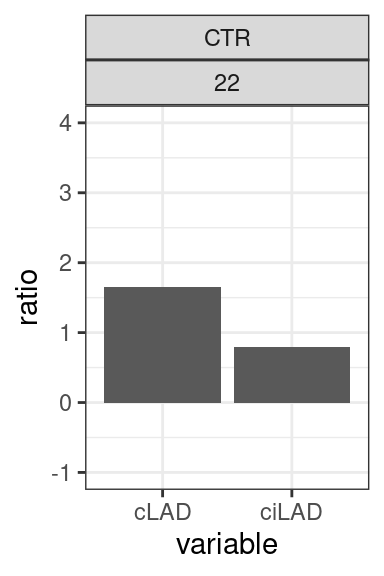

```r
ggplot(LAD_values_driver %>% filter(driver_mut == "CTR")) +
  geom_col(aes(variable, ratio)) +
  facet_wrap(~ reorder(driver_mut, dplyr::desc(driver_n)) + driver_n) +
  theme_bw() + ylim(c(-1,4))
```

#Plot balances per chromatin type

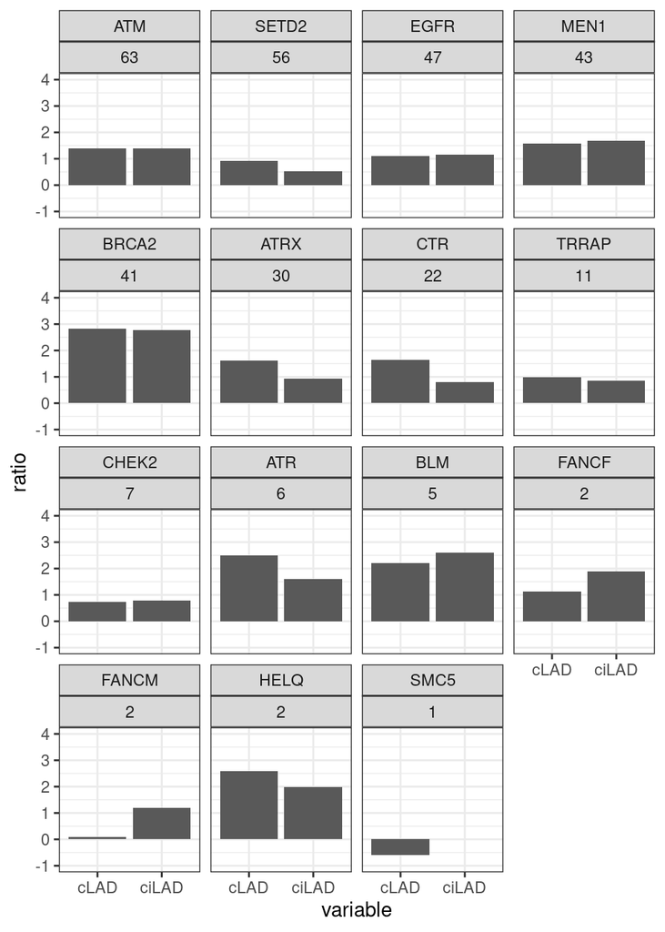

```r
ggplot(LAD_values_driver) +
  geom_col(aes(variable, ratio)) +
  facet_wrap(~ reorder(driver_mut, dplyr::desc(driver_n)) + driver_n) +
  theme_bw() + ylim(c(-1,4))
```

#Plot total number of mutations

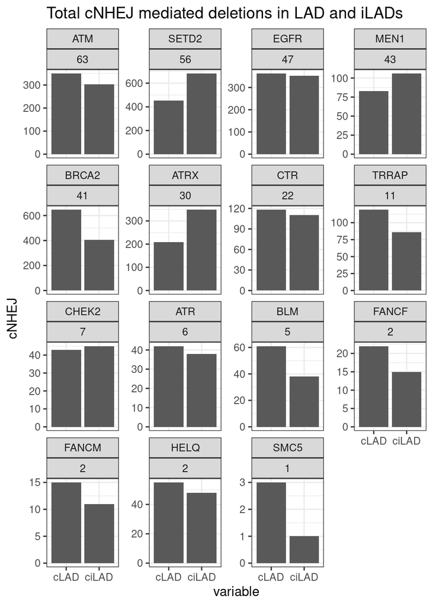

```r
#Total NHEJ deletions
ggplot(LAD_values_driver) +
  geom_col(aes(variable, cNHEJ)) +
  facet_wrap(~ reorder(driver_mut, dplyr::desc(driver_n)) + driver_n, scales = "free_y") +
  theme_bw()+ ggtitle("Total cNHEJ mediated deletions in LAD and iLADs")
```

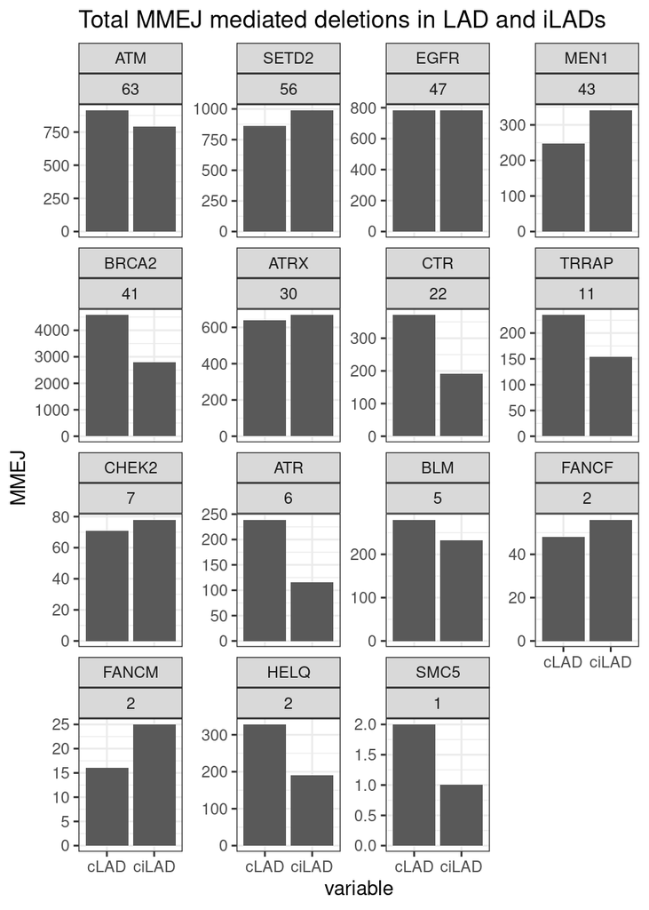

```r
#Total MMEJ deletions
ggplot(LAD_values_driver) +
  geom_col(aes(variable, MMEJ)) +
  facet_wrap(~ reorder(driver_mut, dplyr::desc(driver_n)) + driver_n, scales = "free_y") +
  theme_bw() + ggtitle("Total MMEJ mediated deletions in LAD and iLADs")
```

#Calculate Fisher test for each driver mutation

```r
#Calculate a fisher test per driver gene
fisher_test <- map_dfr(driver_desc_order, function(x) {
  LAD_values_driver %>%
  filter(driver_mut == x) %>%
  select(cNHEJ, MMEJ,variable) %>%
  column_to_rownames(var = "variable") %>%
  fisher.test() %>% broom::tidy() %>% mutate(driver_mut = x)
}) %>% mutate(fdr = p.adjust(p.value, method = "fdr"),
                                             signif = fdr < 0.05)
```

#CONCLUSION: with this approach several of the proteins validate. But, we need to work on the statistics and get a nice negative control population. For this, it will be important to get bias measurements per sample.

#Test pseudo-count addition

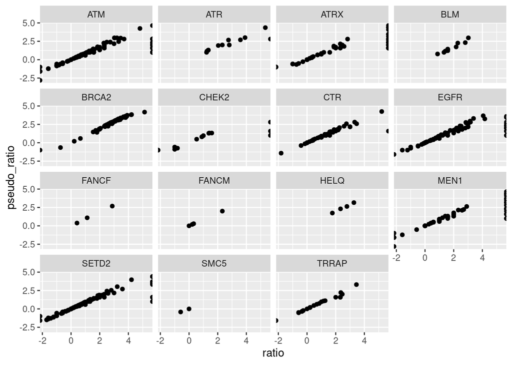

```r
# Prepare data frame per driver mutation.
LAD_values_sample_pseudo <- plot_mutation_chromatin_state_tumor %>%
  reshape2::dcast(driver_mut + variable + sample ~ CLASS, fun.aggregate = sum) %>%
  mutate(pseudo_ratio = log2((MMEJ +1) /(cNHEJ + 1))) %>%
  left_join(summary_table_indels)

#with
LAD_values_sample <- plot_mutation_chromatin_state_tumor %>%
  reshape2::dcast(driver_mut + variable + sample ~ CLASS, fun.aggregate = sum) %>%
  mutate(ratio = log2((MMEJ) /(cNHEJ))) %>%
  left_join(summary_table_indels)

#Merge for control
control_pseudomut <- LAD_values_sample_pseudo %>%
  left_join(LAD_values_sample)

#quick control plot
ggplot(control_pseudomut) +
  geom_point(aes(ratio, pseudo_ratio)) +
  facet_wrap(~ driver_mut)
```

#First control: Calculate by tissue

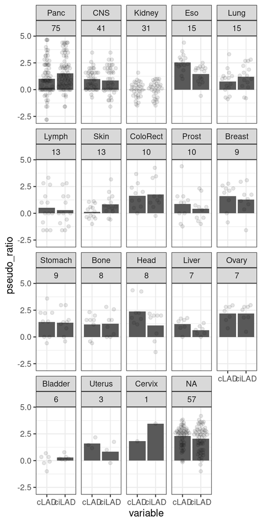

```r
ggplot(LAD_values_sample_pseudo, aes(variable, pseudo_ratio)) +
  stat_summary(geom = "bar", fun = "mean") +
  geom_quasirandom(alpha = 0.1) +
  facet_wrap(~ reorder(tissue, dplyr::desc(tissue_n)) + tissue_n) +
  theme_bw()
```

#Calculate control balances with pseudo-count

```
## No summary function supplied, defaulting to `mean_se()`
```

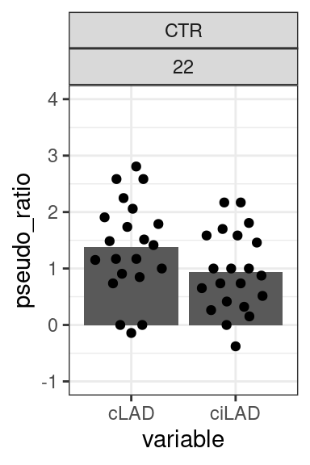

```r
ggplot(LAD_values_sample_pseudo %>% filter(driver_mut == "CTR"), aes(variable, pseudo_ratio)) +
  stat_summary(geom = "bar") +
  geom_quasirandom() +
  facet_wrap(~ reorder(driver_mut, dplyr::desc(driver_n)) + driver_n) +
  theme_bw() + ylim(c(-1,4))
```

#Plot all the rest

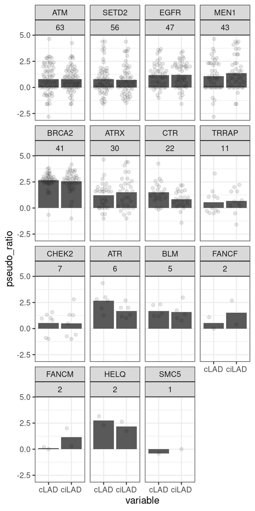

```r
ggplot(LAD_values_sample_pseudo, aes(variable, pseudo_ratio)) +
  stat_summary(geom = "bar", fun = "mean") +
  geom_quasirandom(alpha = 0.1) +
  facet_wrap(~ reorder(driver_mut, dplyr::desc(driver_n)) + driver_n) +
  theme_bw()
```

#CONCLUSION: Overall, there are not so many changes if you calculate per tumor with a pseudocount of total amoount of deletion. For z-score calculation, I think is better if we keep them separately and compare it to a null-distribution generated by permutation.

#Additional checks before meeting with mathijs

#Calculate for each tumor_type

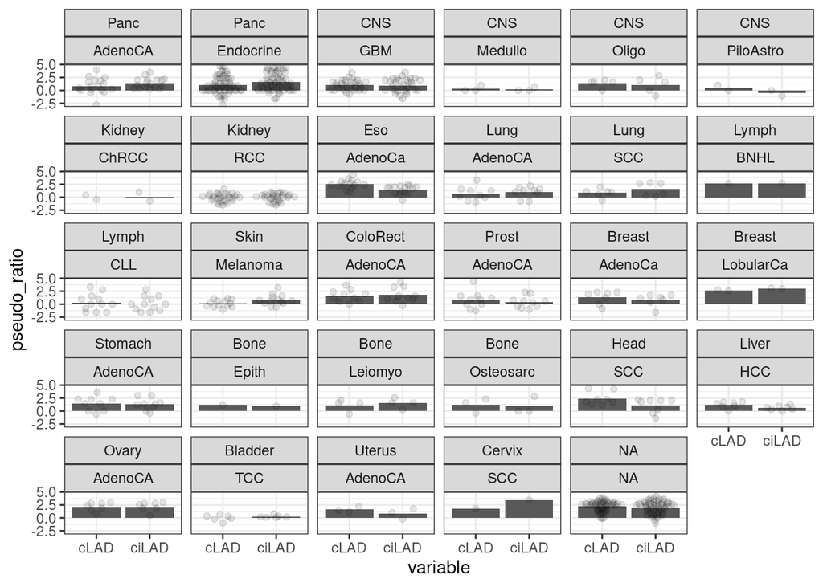

```r
ggplot(LAD_values_sample_pseudo, aes(variable, pseudo_ratio)) +
  stat_summary(geom = "bar", fun = "mean") +
  geom_quasirandom(alpha = 0.1) +
  facet_wrap(~ reorder(tissue, dplyr::desc(tissue_n)) + type) +
  theme_bw()
```

#Calculate ∆balance (delta being LAD vs. iLAD)

```r
# Prepare data frame per driver mutation.
LAD_values_sample_pseudo_diff <- plot_mutation_chromatin_state_tumor %>%
  reshape2::dcast(driver_mut + variable + sample ~ CLASS, fun.aggregate = sum) %>%
  mutate(pseudo_ratio = log2((MMEJ +1) /(cNHEJ + 1))) %>%
  reshape2::dcast(driver_mut + sample ~ variable, value.var = "pseudo_ratio") %>%
  mutate(diff_balance = cLAD - ciLAD) %>%
  left_join(summary_table_indels)# Prepare data frame per driver mutation.
```

#How variable this metric is?: Per tissue

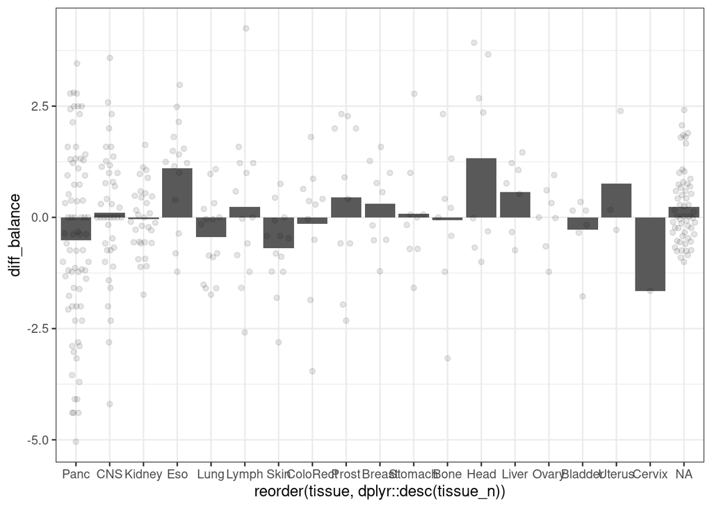

```r
ggplot(LAD_values_sample_pseudo_diff, aes(reorder(tissue, dplyr::desc(tissue_n)), diff_balance)) +
  stat_summary(geom = "bar", fun = "mean") +
  geom_quasirandom(alpha = 0.1) +
  theme_bw()
```

#Measure per driver mutation

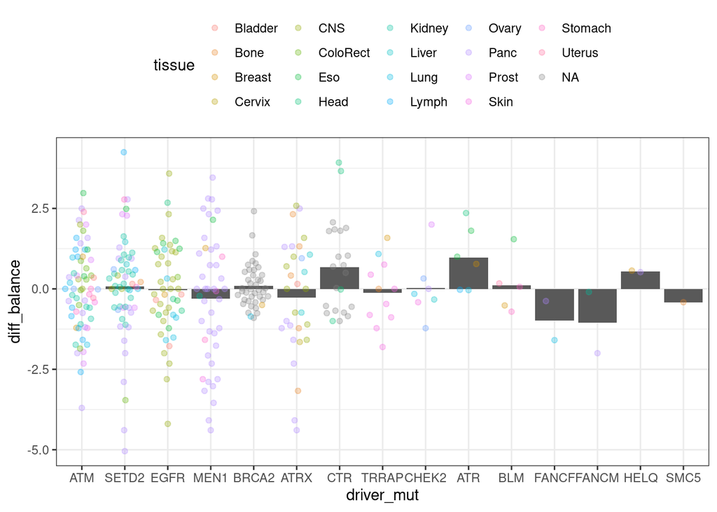

```r
ggplot(LAD_values_sample_pseudo_diff, aes(reorder(driver_mut, dplyr::desc(driver_n)), diff_balance)) +
  stat_summary(geom = "bar", fun = "mean") +
  geom_quasirandom(alpha = 0.3, aes(color = tissue)) +
  theme_bw() +
  theme(legend.position = "top") +
  xlab("driver_mut")
```

#Play with Stoufer’s test (even if it is not the best control set)

```r
#controol distributions
control_distributions <- LAD_values_sample_pseudo_diff %>%
  dplyr::group_by(tissue) %>%
  dplyr::summarise(mean_tissue = mean(diff_balance),
                   sd_tissue = sd(diff_balance))

#Normalize to controls
z_score_differential <- LAD_values_sample_pseudo_diff %>%
  left_join(control_distributions) %>%
  mutate(z_score_diff = (diff_balance - mean_tissue)/sd_tissue)
#Average per driver
stouffer_mean <- z_score_differential %>%
  dplyr::group_by(driver_mut) %>%
  dplyr::summarise(stouf_z = mean(z_score_diff)/sqrt(n()))
```

#Plot the z-score values

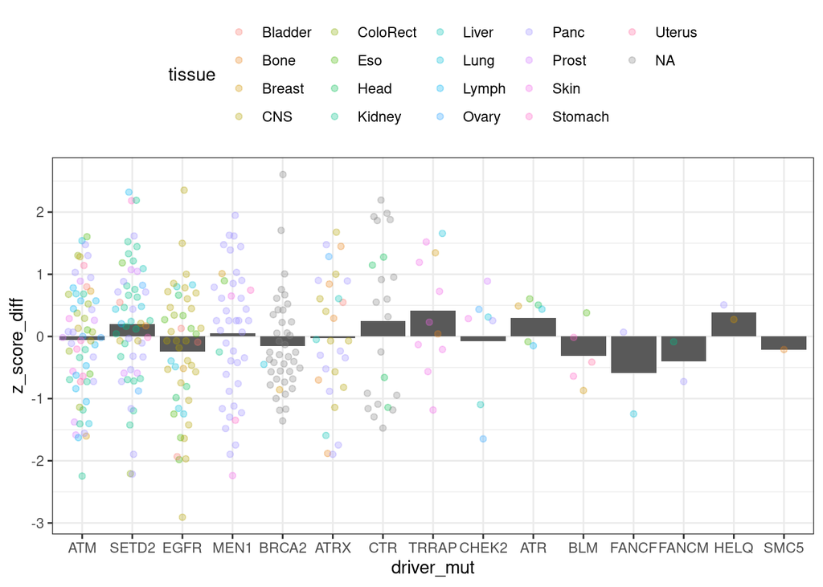

```r
ggplot(z_score_differential, aes(reorder(driver_mut, dplyr::desc(driver_n)), z_score_diff)) +
  stat_summary(geom = "bar", fun = "mean") +
  geom_quasirandom(alpha = 0.3, aes(color = tissue)) +
  theme_bw() +
  theme(legend.position = "top") +
  xlab("driver_mut")
```